# Teste T de Student para Duas Médias

Douglas Vinícius

19/06/2019

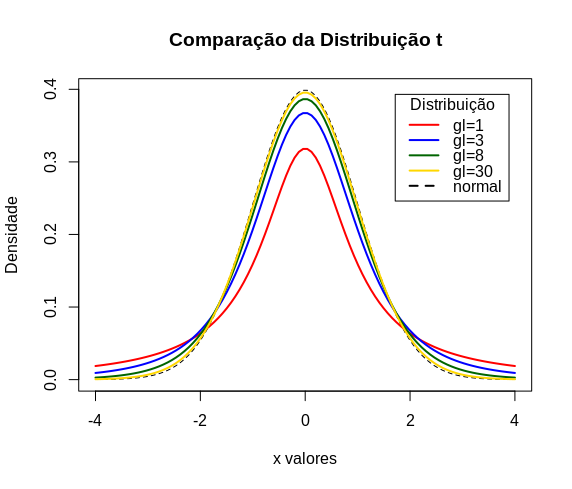

Distribuição t comparada com a normal.

Aplicação Shiny da distribuição t: [T-test](https://douglas-vincius.shinyapps.io/T-test-shiny/)

## Teste T para Duas $\mu$ (Amostras Independentes e $\sigma²$ Iguais)

Este método é usado para dados amostrais provenientes de duas amostras independentes para o teste de hipóteses feitas sobre duas médias populacionais. Destina a situação de dois desvios-padrão populacionais são desconhecidos, mas se supõe que sejam iguais.

## Requisitos

- Os dois desvios-padrão populacionais não são conhecidos, mas supõe-se quw sejam iguais, isto é, $\sigma_{1}$ = $\sigma_{2}$.
- As duas amostras são independentes.
- Ambas as amostras são *amostras aleatórias simples*.
- Uma ou as duas condições seguintes são satisfeitas: Os dois tamanhos amostrais são ambos *grandes* (com n<sub>1</sub> > 30 e n<sub>2</sub> > 30), ou ambas as amostras provêm de populações com distibuições normais. (Para pequenas amostras, a exigência de normalidade é relaxada, no sentido de que os procedimentos funcionam bem desde que não haja *outliers* e os desvios da normalidade naõ sejam extremos.)

### O que é Amostras Independentes?

Duas amostras são *independentes* se os valores amostrais de uma população não estão relacionados ou, de alguma forma, emparelhados ou combinados com os valores amostrais selecionados da outra população.

### Estatística de Teste:

$$t = \frac{(\bar{x}_1 - \bar{x}_2) - (\mu_1 - \mu_2)}{\sqrt{\frac{s_p²}{n_1} + \frac{s_p²}{n_2}}}$$
em que

$$S_p² = \frac{(n_1 - 1)s_1² + (n_2 - 1)s_2²}{(n_1 - 1) + (n_2 - 1)} \textrm{(Variância combinada)}$$
e o número de graus de liberdade é dado por gl $= n_1 + n_2 - 2$.

### Exemplo

- Um estudo objetivou analisar a associação entre a síndrome metabólica (SM) em indivíduos de origem japonesa, com mais de 30 anos de idade, residentes em um município do interior de São Paulo. -População 1: indivíduos com SM. -População 2: indivíduos sem SM.

Pergunta-se? Indivíduos com SM e sem SM possuem, em média, valores iguais para a pressão arterial sistólica(PAS)?

- $\mu_1$ é a média da PAS na população 1;
- $\mu_2$ é a média da PAS na população 2.

Testando as hipóteses:
$$H_0: \mu_1 = \mu_2
\\H_a: \mu_1 \neq \mu_2$$

Lembrando que $\sigma_1$ é o desvio padrão da PAS na população 1, e $\sigma_2$ é o desvio padrão da PAS na população 2; Pressupondo que
$$\sigma = \sigma_1 = \sigma_2$$
.

Teremos
$$S_p² = \frac{(n_1 - 1)s_1² + (n_2 - 1)s_2²}{(n_1 + n_2 - 2)}$$

Lembrando que o teste t<sub>cal</sub> é um valor de uma variável aleatória que segue uma distribuição t Student com n<sub>1</sub> + n<sub>2</sub> − 2 graus de liberdade.

$$t_{cal} = \frac{(\bar{x}_1 - \bar{x}_2)}{\sqrt{\frac{s_p²}{n_1} + \frac{s_p²}{n_2}}}$$
em que
$$S_p² = \frac{(n_1 - 1)s_1² + (n_2 - 1)s_2²}{(n_1 + n_2 - 2)}$$
.

- Seja o tamanho das amostras da população 1 igual 52 e população 2 igual 50.
- Seja um nível de significância $\alpha$ = 0,05; 1 - $\alpha$ = 0,95.
- O número de graus de liberdade é 52+50-2=100.

Imagem adquirirda no link:https://douglas-vincius.shinyapps.io/T-test-shiny/

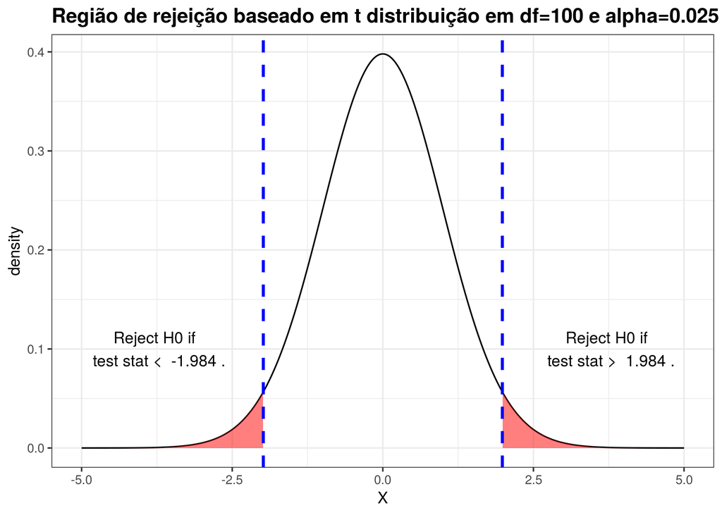